# Stat135-Lab12

Yutong Wang

4/24/2020

```r
library(tidyverse)
```

## Loading Data

Remember to set `stringsAsFactors = FALSE` when you load data. You can also load data from Files -> Import Dataset -> From Text (base).

```r
barium <- read.delim("./barium.txt", comment.char="#", stringsAsFactors=FALSE)
names(barium) <- c("temp", "pressure")
```

Specify the response variable as $\log(\text{pressure})$, and the predictor variable as $\frac{1}{\text{temperature}}$. You can use either baseR or dplyr.

```r
# dplyr
barium <- barium %>%
  mutate(lnpressure = log(pressure)) %>%
  mutate(invtemp = temp^(-1))

# baseR
# barium$lnpressure <- log(barium$pressure)
# barium$invtemp <- (barium$temp)^(-1)
```

Now plot the second law of thermodynamics, and see if there is indeed any linear relationship.

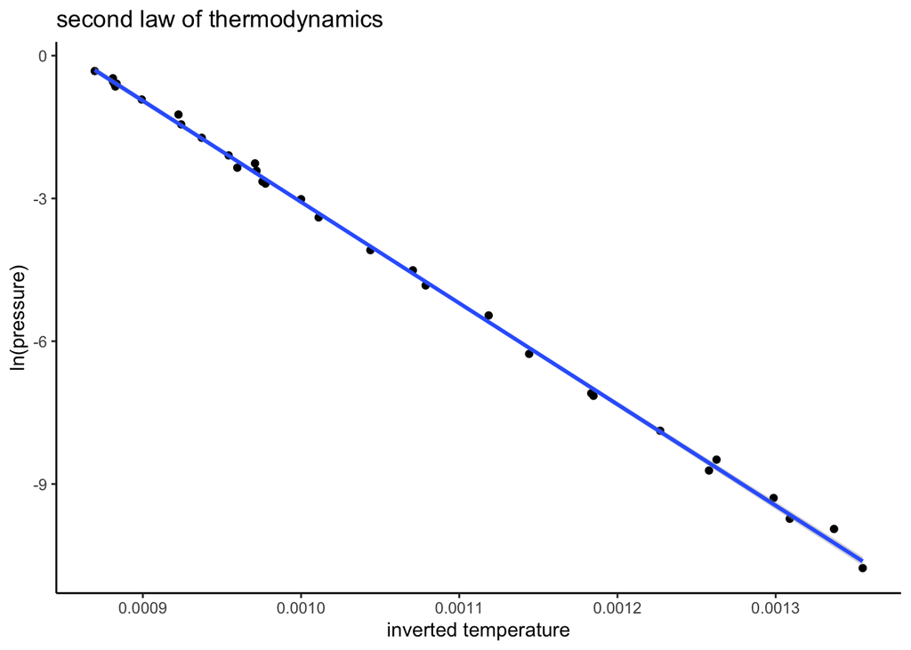

```r
ggplot(barium, aes(x = invtemp, y = lnpressure)) +
  geom_point() +
  geom_smooth(method = "lm") +
  xlab("inverted temperature") +
  ylab("ln(pressure)") +
  ggtitle("second law of thermodynamics") +
  theme_classic()
```

## Estimation

You can either use `lm()` function, or manually compute the estimated values.

### Solution 1

Use the covariance and variance to estimate the regression coefficients. This solution only works in the simple linear regression scenario.

$\hat{\beta}_1$ is

```r
B_hat <- cov(barium$lnpressure, barium$invtemp)/var(barium$invtemp)
B_hat
```

```
## [1] -21259.69
```

$\hat{\beta}_0$ is

```r
A_hat <- mean(barium$lnpressure) - B_hat * mean(barium$invtemp)
A_hat
```

```
## [1] 18.1847
```

### Solution 2

Use the analytical solution in the matrix form.

```r
design_mat <- cbind(rep(1, nrow(barium)),
                    barium$invtemp)
solve(t(design_mat) %*% design_mat) %*% t(design_mat) %*% barium$lnpressure
```

```
##             [,1]
## [1,]     18.1847
## [2,] -21259.6919
```

### Solution 3

Use built-in `lm()` function to derive the estimated coefficients.

```r
linear_model <- lm(lnpressure ~ invtemp, data = barium)
result <- summary(linear_model)
coef(result)[, 1]
```

```
## (Intercept)     invtemp
##     18.1847 -21259.6919
```

```r
result$coefficients[, 1]
```

```
## (Intercept)     invtemp
##     18.1847 -21259.6919
```

## Statistical Properties

### Solution 1

The summary of the linear model object also contains the standard error of our estimates of the regression coefficients.

```r
coef(result)[, 2]
```

```
## (Intercept)     invtemp
##   0.1418549 133.4539677
```

```r
result$coefficients[, 2]
```

```
## (Intercept)     invtemp
##   0.1418549 133.4539677
```

### Solution 2

We can also manually compute the standard error. First let us estimate $\sigma^2$.

```r
sigma_sq_hat <- sum(result$residuals**2)/(nrow(barium) - 2)
sigma_sq_hat
```

```
## [1] 0.01354334
```

Then, you can plug in into the formulas.